# 25Sept2018

### Considering and not considering topology

We are interested on see what is the impact of considering or not considering topology on the emphasis approach

$$\begin{equation} \label{lik2} f_X(x,y;\phi) = \underbrace{\left(\prod_{i=1}^{d} e^{-s_i\left[\Delta t_i-\frac{e^{-T\mu_0}}{\mu_0} (e^{\Delta t_i \mu_0}-1)\right]}\right)}_\text{missing speciations}\underbrace{\left(\prod_{i=1}^{d} e^{-s_i\frac{e^{-T \mu_0}}{\mu_0}(e^{\Delta t_i \mu_0}-1)} \right)}_\text{extant speciations}\underbrace{\left(\prod_{i=1}^{m} e^{-\mu_0 t_{i}^{(ext)}}\right)}_\text{extinctions}\underbrace{\left( \prod_{i=1}^{d-1} \rho_i \right)}_\text{topology} \end{equation}$$

where

$$\rho_i= \begin{cases}
\lambda_{j} & \text{if speciation of species j takes place at time } t_i \\
\mu_{0} & \text{if extinction of species j takes place at time } t_i
\end{cases}$$

the probability density of the missing part of the tree would be then

$$\begin{equation} \label{sak2} g_X(x;\phi) = \underbrace{\left(\prod_{i=1}^{d} e^{-s_i\left[\Delta t_i-\frac{e^{-T\mu_0}}{\mu_0} ( e^{\Delta t_i \mu_0}-1)\right]}\right)}_\text{missing speciations}\underbrace{\left(\prod_{i=1}^{m} e^{-\mu_0 t_{i}^{(ext)} }\right)}_\text{extinctions}\underbrace{\left( \prod_{i=1}^{2m} \rho_{(m_i)} \right)}_\text{missing topology} \end{equation}$$

We define

$$w_i = \frac{f_{X,Y}(x,y;\phi)}{g_X(x;\phi)} = \left(\prod_{i=1}^{d} e^{-s_i\frac{e^{-T \mu_0}}{\mu_0}(e^{\Delta t_i \mu_0}-1)} \right)\left( \prod_{i \neq M} \lambda_i \right)$$

where $M = \{m_1, ... , m_m\}$

Empirically, we use the case of Dendroica data and it corresponding MLE. Then on top of that tree we simulate missing data and observe the distribution of weights in relationship with the dimension of the trees.

```r
#dendroica
btdd = c(4.9999999998,4.806886544,4.70731246478,4.50735197578,4.37856240588,4.29594855558,4.19207515688,4.18261061218,4.11238451758,4.09640902445,3.81723693538,3.71143733895,3.48845298905,3.25729503338,3.11613886835,2.64829864145,2.63531839038,2.37990087748,1.82721570435,0.83704715535,0.64242044758,0.56121103655,0.356333544350001,0.346462849050001)
DDD = DDD::dd_ML(brts = btdd, idparsopt = 1:3)
```

```
## You are optimizing lambda mu K
## You are fixing nothing
## Optimizing the likelihood - this may take a while.
## The loglikelihood for the initial parameter values is -56.69187
##
##  Maximum likelihood parameter estimates: lambda: 3.021189, mu: 0.164449, K: 24.579503
##  Maximum loglikelihood: -38.734581
```

```r
mle_pars = c(DDD$lambda,DDD$mu,DDD$K)
time = proc.time()
S = sim.sct(brts = btdd,pars = mle_pars,m = 100000)
```

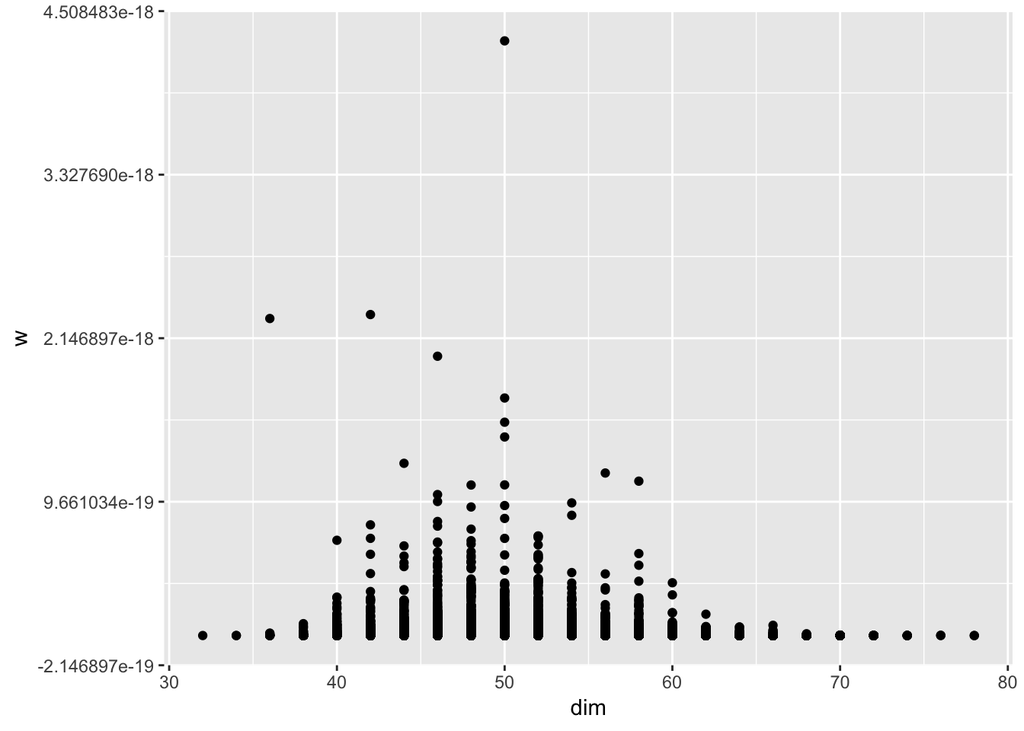

```r
get.time(time)
```

```
## [1] 83.817
```

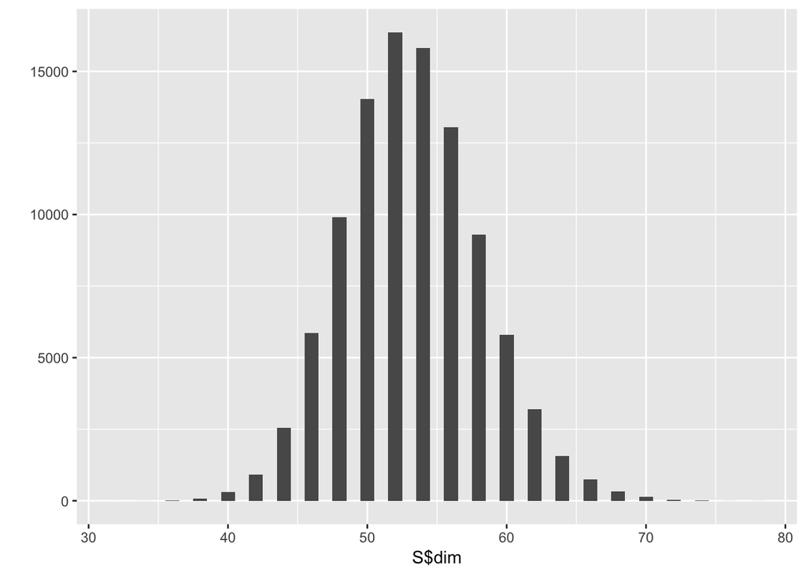

```r
qplot(S$dim, geom="histogram",binwidth=1)
```

```r
time = proc.time()
mle.st(S)$par
```

```
## [1]  3.1894512  0.1301227 24.4854019
```

```r
get.time(time)
```

```
## [1] 1059.449
```

On the case of not considering topology the corresponding functions would be the same

$$\begin{equation} \label{lik52} f_X(x,y;\phi) = \underbrace{\left(\prod_{i=1}^{d} e^{-s_i\left[\Delta t_i-\frac{e^{-T\mu_0}}{\mu_0} (e^{\Delta t_i \mu_0}-1)\right]}\right)}_\text{missing speciations}\underbrace{\left(\prod_{i=1}^{d} e^{-s_i\frac{e^{-T \mu_0}}{\mu_0}(e^{\Delta t_i \mu_0}-1)} \right)}_\text{extant speciations}\underbrace{\left(\prod_{i=1}^{m} e^{-\mu_0 t_{i}^{(ext)}}\right)}_\text{extinctions}\underbrace{\left( \prod_{i=1}^{d-1} \rho_i \right)}_\text{topology} \end{equation}$$

but with

$$\rho_i= \begin{cases}
s_i & \text{if speciation at time } t_i \\
\mu_0 & \text{if extinction at time } t_i
\end{cases}$$

and the distribution of the missing part

$$\begin{equation} \label{sak24} g_X(x;\phi) = \underbrace{\left(\prod_{i=1}^{d} e^{-s_i\left[\Delta t_i-\frac{e^{-T\mu_0}}{\mu_0} ( e^{\Delta t_i \mu_0}-1)\right]}\right)}_\text{missing speciations}\underbrace{\left(\prod_{i=1}^{m}\mu_0 e^{-\mu_0\Delta t_i}\right)}_\text{extinctions}\underbrace{\left( \prod_{i=1}^{m} s_{(m_i)} \right)}_\text{topology} \end{equation}$$

```r
time = proc.time()
S = sim.sct(brts = btdd,pars = mle_pars,m = 100000,topology = FALSE)
```

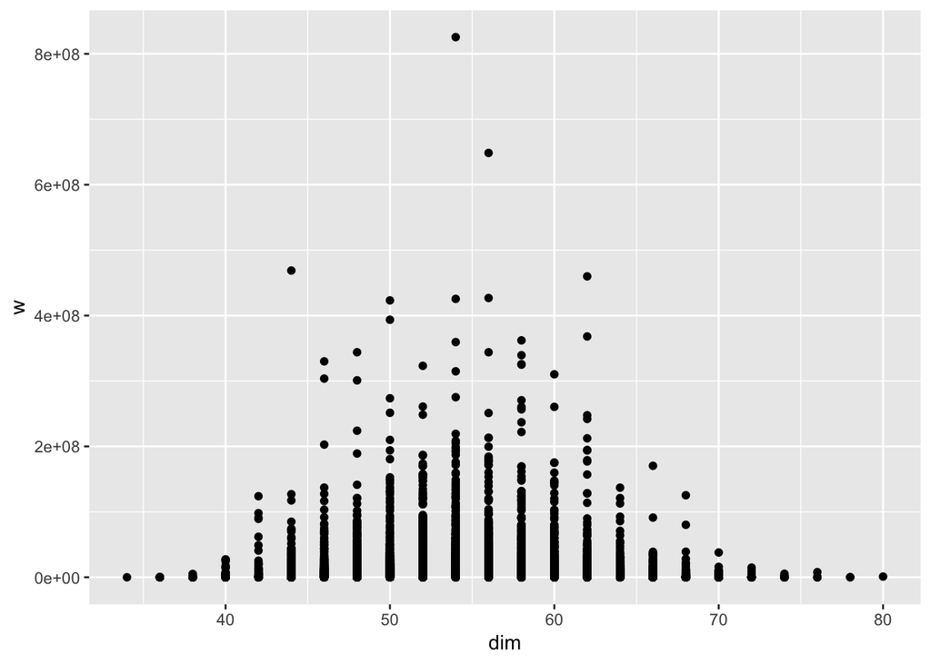

```r
get.time(time)
```

```
## [1] 79.906
```

```r
time = proc.time()
mle.st(S,topology=FALSE)$par
```

```
## [1]  3.8389117  0.1431961 24.4826989
```

```r
get.time(time)
```

```
## [1] 1222.123
```

and mle

```r
newS = sub.st(S)
mlesub = mle.st(newS,topology=FALSE)$par
mlesub
```

```
## [1]  4.8799514  0.1439037 24.5468807
```

```r
time = proc.time()
S = sim.sct(brts = btdd,pars = mle_pars,m = 100000)
```

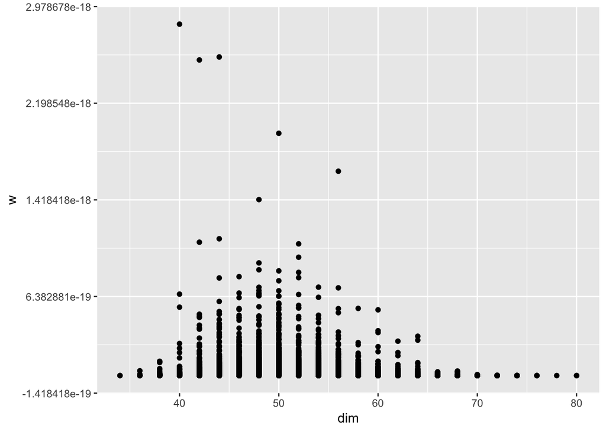

```r
get.time(time)
```

```
## [1] 94.049
```

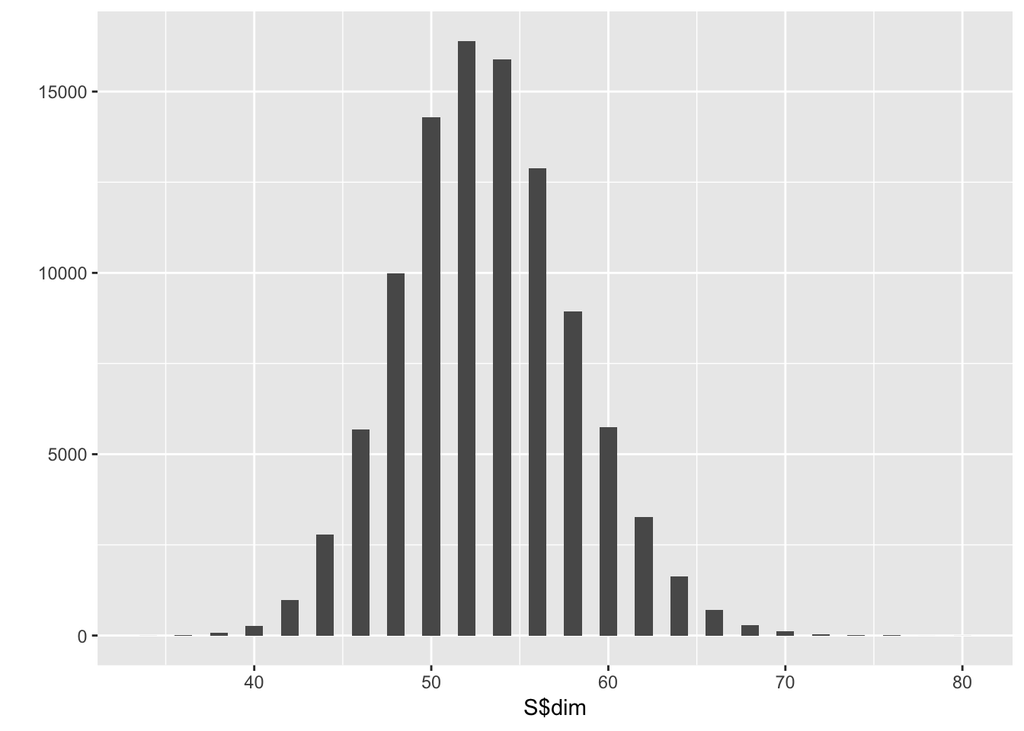

```r
qplot(S$dim, geom="histogram",binwidth=1)
```

mle

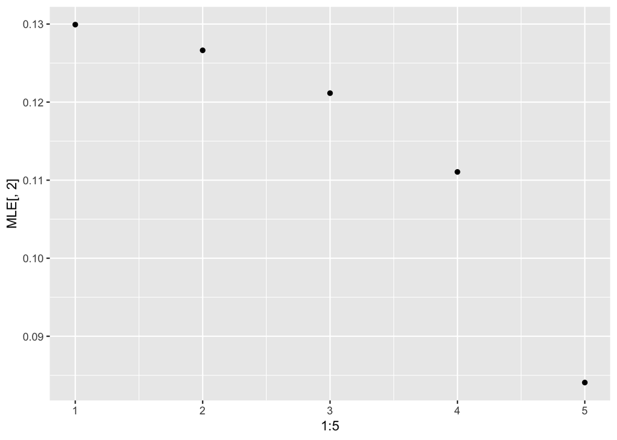

```r
best = c(10000,1000,100,10,1)
times = NULL
MLE = matrix(nrow = 5,ncol = 3)
for(i in 1:5){
  newS = sub.st(S,ntrees = best[i])
  time = proc.time()
  MLE[i,] = mle.st(newS)$par
  times[i] = get.time(time)
}
qplot(1:5,MLE[,2])
```

```r
times
```

```
## [1] 99.643  9.580  0.934  0.072  0.029
```

```r
MLE
```

```
##          [,1]       [,2]     [,3]
## [1,] 3.217232 0.12993124 24.49726
## [2,] 3.305124 0.12663538 24.54263
## [3,] 3.349613 0.12114586 24.58793
## [4,] 3.465364 0.11105538 24.66538
## [5,] 2.478003 0.08407075 25.06654
```

Larger sampling size without topology

```r
time = proc.time()
S = sim.sct(brts = btdd,pars = mle_pars,m = 100000,topology = FALSE)
```

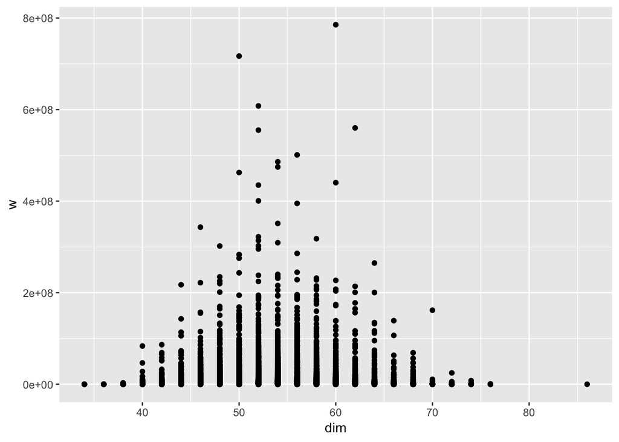

```r
get.time(time)
```

```
## [1] 79.258
```

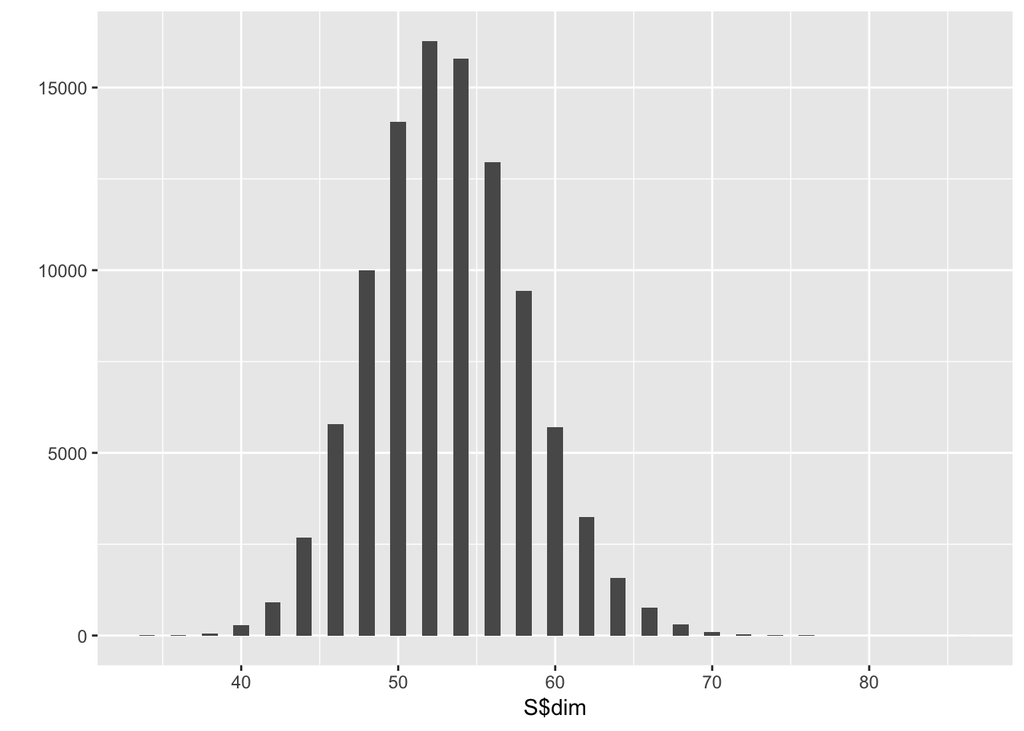

```r
qplot(S$dim, geom="histogram",binwidth=1)
```

mle

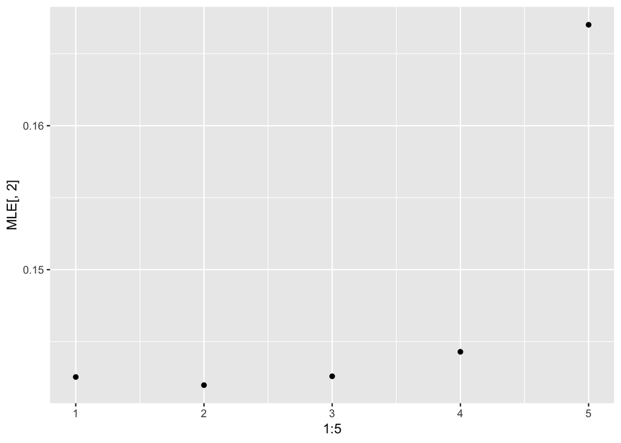

```r
best = c(10000,1000,100,10,1)
times = NULL
MLE = matrix(nrow = 5,ncol = 3)
for(i in 1:5){
  newS = sub.st(S,ntrees = best[i])
  time = proc.time()
  MLE[i,] = mle.st(newS,topology = FALSE)$par
  times[i] = get.time(time)
}
qplot(1:5,MLE[,2])
```

```r
times
```

```
## [1] 116.776  12.928   1.348   0.087   0.009
```

```r
MLE
```

```
##          [,1]      [,2]     [,3]
## [1,] 3.910688 0.1425427 24.49878
## [2,] 4.294329 0.1419777 24.54407
## [3,] 4.714770 0.1425923 24.56543
## [4,] 5.416016 0.1442938 24.59035
## [5,] 5.681812 0.1670135 24.49279
```

if I do it again?

```r
time = proc.time()
S = sim.sct(brts = btdd,pars = mle_pars,m = 100000,topology = FALSE)
```

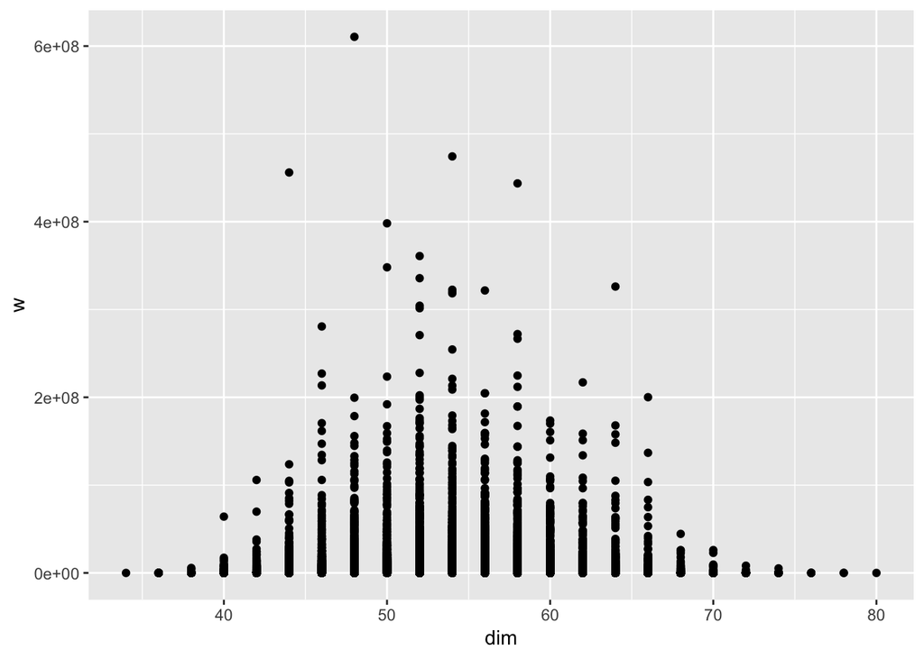

```r
get.time(time)
```

```
## [1] 178.867
```

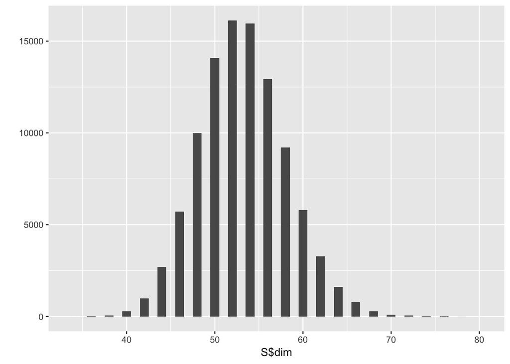

```r
qplot(S$dim, geom="histogram",binwidth=1)
```

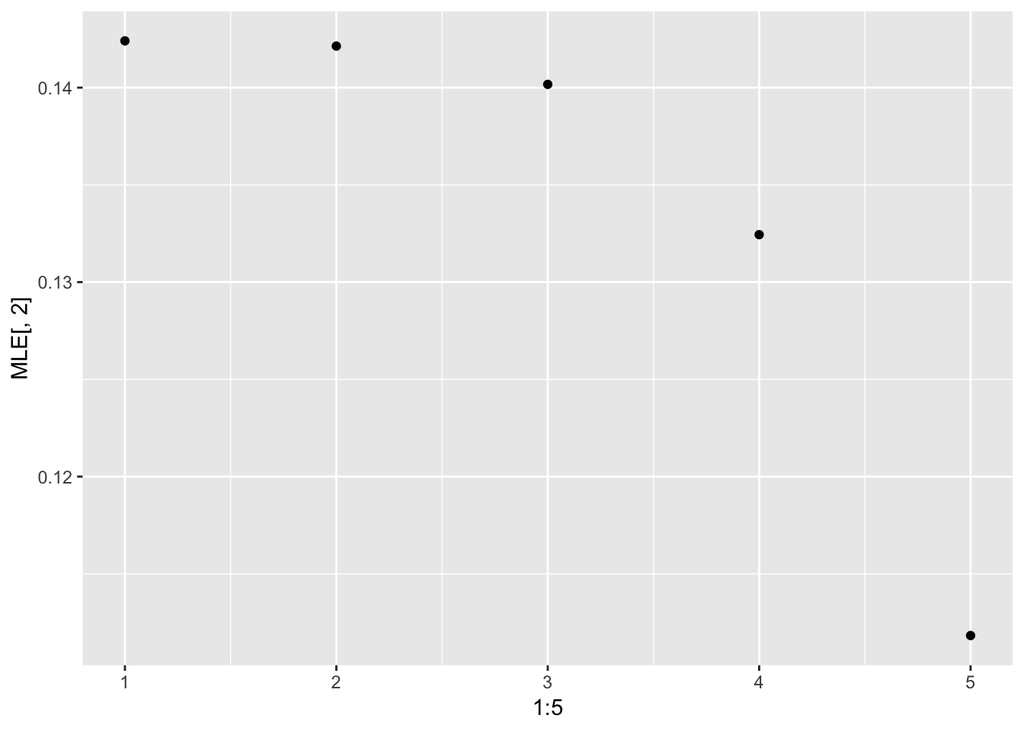

```r
best = c(10000,1000,100,10,1)
times = NULL
MLE = matrix(nrow = 5,ncol = 3)
for(i in 1:5){
  newS = sub.st(S,ntrees = best[i])
  time = proc.time()
  MLE[i,] = mle.st(newS,topology = FALSE)$par
  times[i] = get.time(time)
}
qplot(1:5,MLE[,2])
```

```r
times
```

```
## [1] 328.855  35.824   3.787   0.512   0.028
```

```r
MLE
```

```
##          [,1]      [,2]     [,3]
## [1,] 3.856114 0.1424046 24.49175
## [2,] 4.201349 0.1421362 24.53062
## [3,] 4.534875 0.1401683 24.55573
## [4,] 4.697571 0.1324400 24.58199
## [5,] 4.862249 0.1118284 24.71673
```

even Larger sampling size

```r
time=proc.time()
load("~/Google Drive/emphasis/1Mtrees.RData")
get.time(time)
best = c(10000,1000,100,10,1)
times = NULL
MLE = matrix(nrow = 5,ncol = 3)
for(i in 1:5){
  newS = sub.st(St,ntrees = best[i])
  time = proc.time()
  MLE[i,] = mle.st(newS)$par
  times[i] = get.time(time)
}
qplot(1:5,MLE[,2])
```

[output not shown]

### Is it really possible to optimize directly without EM?

Using the idea of previous meetings:

$$L(y | \theta) = \frac{1}{m}\sum_{i=1}^m f(x_i,y|\theta)\frac{1}{g(x_i|y,\theta)}$$

or $L(y|\theta)=\bar{w}$, where $w = (w_1,...,w_m)$ and $w_i = \frac{f(x_i,y|\theta)}{f(x_i,y|\theta)}$.

we are wondering if we can just optimize directly

```r
mc.llik <- function(pars,brts,m){
  S = sim.sct(brts,pars,m,print=FALSE)
  aplli = log(mean(S$w))
  return(aplli)
}

init_par = mle_pars
time = proc.time()
sub = subplex(par = init_par, fn = mc.llik, brts=btdd,m=10)
get.time(time)
print(sub)
```

### Is it first extinction in agreement with the expected sampling probability?

the probability for the first extinction would be defined by

$$g(t=t_0) = \mu_0 \int_{0}^{t_0} \lambda(t) e^{-\Lambda(t)} e^{-\mu_0 (t_0-t)} dt$$

on the case of DD

which is difficult to calculate analitically, so numerical calculations are needed

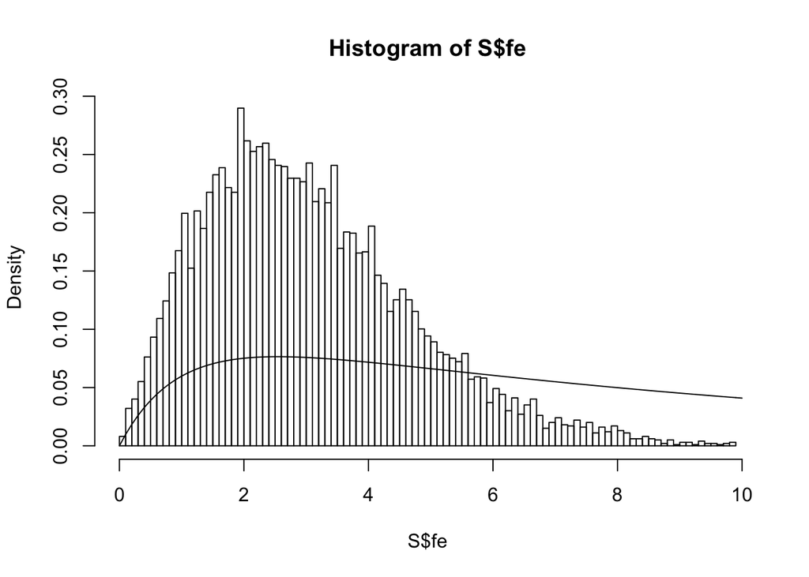

```r
g_ext <- function(mu,s,text,Ti){
  gvec = NULL
  for(i in 1:length(text)){
    integrand <- function(t) mu*s*(1-exp(-mu*(Ti-t)))*exp(-s*(t-exp(-Ti*mu)*(exp(mu*t)-1)/mu)-mu*(text[i]-t))
    gvec = c(gvec,integrate(f = integrand,lower = 0,upper = text[i])$value)
  }
  return(gvec)
}

btdd = 10
pars = c(1,0.1,10)
time = seq(0,btdd[1],by=0.1)
g = g_ext(text=time,mu=pars[2],Ti=btdd[1],s=2*(pars[1]-(pars[1]-pars[2])*2/pars[3]))#/(1-prob)
S = sim.sct(btdd,pars,10000,print=FALSE)
hist(S$fe,prob=TRUE,breaks = 80)
lines(time,g)
```

### some first steps on making the emphasis framework discrete

On the discrete case, the waiting times probability density is

$$f(x,y;\theta) = \prod_i^d(1-p_i)^{\Delta t_i-1}p_i \tau_i$$